# Context:

Businesses like banks that provide service have to worry about the problem of 'Churn' i.e. customers leaving and joining another service provider. It is important to understand which aspects of the service influence a customer's decision in this regard. Management can concentrate efforts on the improvement of service, keeping in mind these priorities.

**Data Description**: The case study is from an open-source dataset from Kaggle. The dataset contains 10,000 sample points with 14 distinct features such as CustomerId, CreditScore, Geography, Gender, Age, Tenure, Balance, etc. Link to the Kaggle project site:https://www.kaggle.com/barelydedicated/bank-customer-churn-modeling

**Data Dictionary:** RowNumber: Row number. CustomerId: Unique identification key for different customers. Surname: Surname of the customer Credit Score: Credit score is a measure of an individual's ability to pay back the borrowed amount. It is the numerical representation of their creditworthiness. A credit score is a 3-digit number that falls in the range of 300-900, 900 being the highest. Geography: The country to which the customer belongs. Gender: The gender of the customer. Age: Age of the customer. Tenure: The period of time a customer has been associated with the bank. Balance: The account balance (the amount of money deposited in the bank account) of the customer. NumOfProducts: How many accounts, bank account affiliated products the person has. HasCrCard: Does the customer have a credit card through the bank? IsActiveMember: Subjective, but for the concept EstimatedSalary: Estimated salary of the customer. Exited: Did they leave the bank after all?

**Points Distribution:** The points distribution for this case is as follows:

1. Read the dataset
2. Drop the columns which are unique for all users like IDs (5 points)
3. Perform bivariate analysis and give your insights from the same (5 points)
4. Distinguish the feature and target set and divide the data set into training and test sets (5 points)
5. Normalize the train and test data (10points)
6. Initialize & build the model. Identify the points of improvement and implement the same. (20)
7. Predict the results using 0.5 as a threshold (10points)
8. Print the Accuracy score and confusion matrix (5 points)

```python
!pip install tensorflow==2.0
```

```python
import tensorflow as tf
print(tf.__version__)
```

```
2.0.0
```

```python
import pandas as pd
import numpy as np
from sklearn.model_selection import train_test_split
import seaborn as sns
import tensorflow as tf
from tensorflow import keras
from sklearn import preprocessing
from tensorflow.keras.models import Sequential
from tensorflow.keras.layers import Dense, Dropout, BatchNormalization
from sklearn.metrics import accuracy_score, confusion_matrix, precision_score, recall_score, f1_score, precision_recall_curve, auc
import matplotlib.pyplot as plt
from tensorflow.keras import optimizers
```

```python
from google.colab import drive
```

```python
drive.mount('/content/drive/')
```

```python
project_path = '/content/drive/My Drive/Colab Notebooks/'
```

```python
dataset_file = project_path + 'bank.csv'
```

**Read the dataset:**

```python
df = pd.read_csv(dataset_file)
```

```python
df.head()
```

|  | RowNumber | CustomerId | Surname | CreditScore | Geography | Gender | Age | Tenure | Balance | NumOfProducts | HasCrCard | IsActiveMember | EstimatedSalary | Exited |
| --- | --- | --- | --- | --- | --- | --- | --- | --- | --- | --- | --- | --- | --- | --- |
| 0 | 1 | 15634602 | Hargrave | 619 | France | Female | 42 | 2 | 0.00 | 1 | 1 | 1 | 101348.88 | 1 |
| 1 | 2 | 15647311 | Hill | 608 | Spain | Female | 41 | 1 | 83807.86 | 1 | 0 | 1 | 112542.58 | 0 |
| 2 | 3 | 15619304 | Onio | 502 | France | Female | 42 | 8 | 159660.80 | 3 | 1 | 0 | 113931.57 | 1 |
| 3 | 4 | 15701354 | Boni | 699 | France | Female | 39 | 1 | 0.00 | 2 | 0 | 0 | 93826.63 | 0 |
| 4 | 5 | 15737888 | Mitchell | 850 | Spain | Female | 43 | 2 | 125510.82 | 1 | 1 | 1 | 79084.10 | 0 |

```python
nexited, exited = np.bincount(df['Exited'])
total = nexited + exited
print('Examples:\n    Total: {}\n    exited: {} ({:.2f}% of total)\n'.format(
    total, exited, 100 * exited / total))
```

```
Examples:
    Total: 10000
    exited: 2037 (20.37% of total)
```

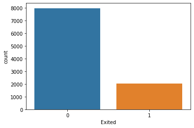

```python
sns.countplot(x='Exited',data = df)
```

**Insights**:Data is highly imbalance.

```python
df_d=pd.DataFrame(df,columns=['RowNumber','CustomerId','Surname','CreditScore','Geography','Gender','Tenure','Balance','NumOfProducts','HasCrCard','IsActiveMember','EstimatedSalary','Exited'])
```

```python
duplicate=df_d[df_d.duplicated(['CustomerId'], keep='first')]
```

```python
print ("Duplicate Rows:")
duplicate
```

```
Duplicate Rows:
```

|  | RowNumber | CustomerId | Surname | CreditScore | Geography | Gender | Tenure | Balance | NumOfProducts | HasCrCard | IsActiveMember | EstimatedSalary | Exited |
| --- | --- | --- | --- | --- | --- | --- | --- | --- | --- | --- | --- | --- | --- |

**Insights:** There is no duplicate customer id.

```python
df.isna().sum()
```

```
RowNumber          0
CustomerId         0
Surname            0
CreditScore        0
Geography          0
Gender             0
Age                0
Tenure             0
Balance            0
NumOfProducts      0
HasCrCard          0
IsActiveMember     0
EstimatedSalary    0
Exited             0
dtype: int64
```

**Drop the columns which are unique for all users like IDs:**

```python
df = df.drop("RowNumber", axis = 1)
```

```python
df = df.drop("CustomerId", axis = 1)
```

```python
df = df.drop("Surname", axis = 1)
```

**Insights:**Surname is not adding any information in analysis , so we are dropping it.

```python
df.describe()
```

|  | CreditScore | Age | Tenure | Balance | NumOfProducts | HasCrCard | IsActiveMember | EstimatedSalary | Exited |
| --- | --- | --- | --- | --- | --- | --- | --- | --- | --- |
| count | 10000.000000 | 10000.000000 | 10000.000000 | 10000.000000 | 10000.000000 | 10000.00000 | 10000.000000 | 10000.000000 | 10000.000000 |
| mean | 650.528800 | 38.921800 | 5.012800 | 76485.889288 | 1.530200 | 0.70550 | 0.515100 | 100090.239881 | 0.203700 |
| std | 96.653299 | 10.487806 | 2.892174 | 62397.405202 | 0.581654 | 0.45584 | 0.499797 | 57510.492818 | 0.402769 |
| min | 350.000000 | 18.000000 | 0.000000 | 0.000000 | 1.000000 | 0.00000 | 0.000000 | 11.580000 | 0.000000 |
| 25% | 584.000000 | 32.000000 | 3.000000 | 0.000000 | 1.000000 | 0.00000 | 0.000000 | 51002.110000 | 0.000000 |
| 50% | 652.000000 | 37.000000 | 5.000000 | 97198.540000 | 1.000000 | 1.00000 | 1.000000 | 100193.915000 | 0.000000 |
| 75% | 718.000000 | 44.000000 | 7.000000 | 127644.240000 | 2.000000 | 1.00000 | 1.000000 | 149388.247500 | 0.000000 |
| max | 850.000000 | 92.000000 | 10.000000 | 250898.090000 | 4.000000 | 1.00000 | 1.000000 | 199992.480000 | 1.000000 |

```python
df.info()
```

```
<class 'pandas.core.frame.DataFrame'>
RangeIndex: 10000 entries, 0 to 9999
Data columns (total 11 columns):
 #   Column           Non-Null Count  Dtype
---  ------           --------------  -----
 0   CreditScore      10000 non-null  int64
 1   Geography        10000 non-null  object
 2   Gender           10000 non-null  object
 3   Age              10000 non-null  int64
 4   Tenure           10000 non-null  int64
 5   Balance          10000 non-null  float64
 6   NumOfProducts    10000 non-null  int64
 7   HasCrCard        10000 non-null  int64
 8   IsActiveMember   10000 non-null  int64
 9   EstimatedSalary  10000 non-null  float64
 10  Exited           10000 non-null  int64
dtypes: float64(2), int64(7), object(2)
memory usage: 859.5+ KB
```

*Perform bivariate analysis and give your insights from the same*

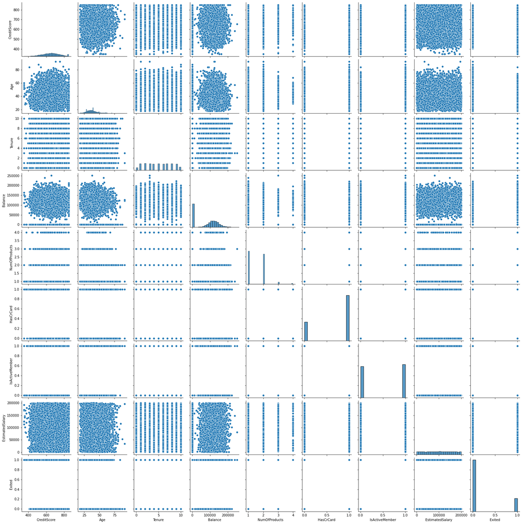

```python
sns.pairplot(data=df)
```

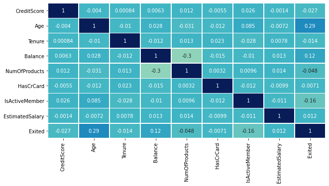

```python
plt.figure(figsize=(10,5))
sns.heatmap(df.corr(),
            annot=True,
            linewidths=.5,
            center=0,
            cbar=False,
            cmap="YlGnBu")
plt.show()
```

**Insights:** There is no significant co-relation between any of the column.

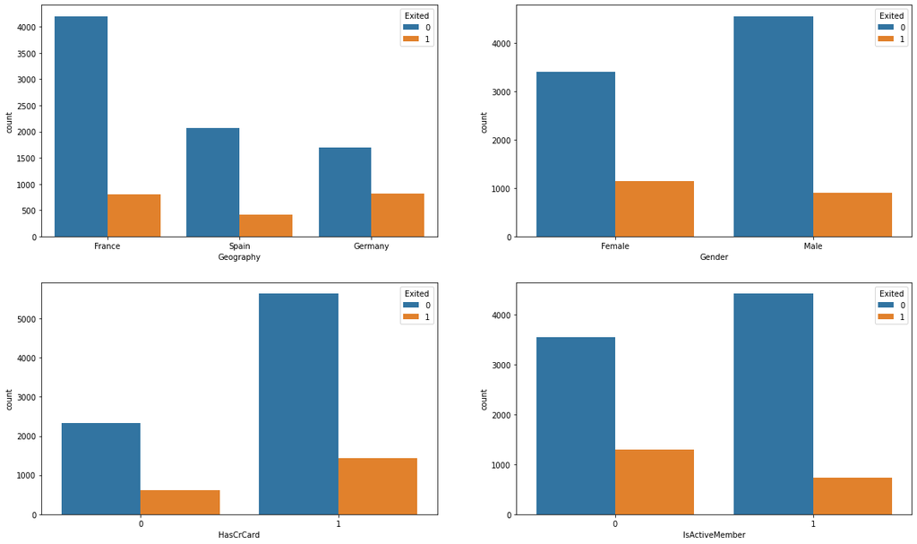

```python
fig, axarr = plt.subplots(2, 2, figsize=(20, 12))
sns.countplot(x='Geography', hue = 'Exited',data = df,ax=axarr[0][0])
sns.countplot(x='Gender', hue = 'Exited',data = df, ax=axarr[0][1])
sns.countplot(x='HasCrCard', hue = 'Exited',data = df, ax=axarr[1][0])
sns.countplot(x='IsActiveMember', hue = 'Exited',data = df, ax=axarr[1][1])
```

```python
df = pd.get_dummies(df, columns=['Gender'])
df = pd.get_dummies(df, columns=['Geography']) # one hot encoding for geography column in order to convert it into integer
```

```python
df.head()
```

|  | CreditScore | Age | Tenure | Balance | NumOfProducts | HasCrCard | IsActiveMember | EstimatedSalary | Exited | Gender_Female | Gender_Male | Geography_France | Geography_Germany | Geography_Spain |
| --- | --- | --- | --- | --- | --- | --- | --- | --- | --- | --- | --- | --- | --- | --- |
| 0 | 619 | 42 | 2 | 0.00 | 1 | 1 | 1 | 101348.88 | 1 | 1 | 0 | 1 | 0 | 0 |
| 1 | 608 | 41 | 1 | 83807.86 | 1 | 0 | 1 | 112542.58 | 0 | 1 | 0 | 0 | 0 | 1 |
| 2 | 502 | 42 | 8 | 159660.80 | 3 | 1 | 0 | 113931.57 | 1 | 1 | 0 | 1 | 0 | 0 |
| 3 | 699 | 39 | 1 | 0.00 | 2 | 0 | 0 | 93826.63 | 0 | 1 | 0 | 1 | 0 | 0 |
| 4 | 850 | 43 | 2 | 125510.82 | 1 | 1 | 1 | 79084.10 | 0 | 1 | 0 | 0 | 0 | 1 |

**Distinguish the feature and target set and divide the data set into training and test sets**

```python
from sklearn.model_selection import train_test_split

# Specify the data
X=df.drop("Exited", axis = 1)

# Specify the target labels and flatten array
Y= df.Exited


# Split the data up in train and test sets
X_train, X_test, Y_train, Y_test = train_test_split(X, Y, test_size=0.20, random_state=42)

#Y_train =  np.array(Y_train)
#Y_test =  np.array(Y_test)
```

**Normalize the train and test data**

```python
from sklearn.preprocessing import StandardScaler

# Define the scaler
scaler = StandardScaler()

# Scale the train set
X_train = scaler.fit_transform(X_train)

# Scale the test set
X_test = scaler.transform(X_test)
```

```python
print(X.shape)
print(Y.shape)
```

```
(10000, 13)
(10000,)
```

```python
print(X_train.shape)
print(X_test.shape)
print(Y_train.shape)
print(Y_test.shape)
```

```
(8000, 13)
(2000, 13)
(8000,)
(2000,)
```

**Initialize & build the model. Identify the points of improvement and implement the same.**

```python
model = Sequential()
```

```python
# Add the first hidden layer
model.add(Dense(800, input_shape = (13,), activation = 'relu'))
# Adding the second hidden layer
model.add(Dense(100, activation = 'relu'))
# Adding the output layer
model.add(Dense(1, activation = 'sigmoid'))
```

input_shape refers to the number of input/independent features.

activation_function: Activation function decides whether a neuron should be activated or not by calculating the weighted sum and further adding bias with it. The purpose of the activation function is to introduce non-linearity into the output of a neuron. Two types of activation functions: RELU and SIGMOID are used to build a model.

```python
METRICS = [
      keras.metrics.TruePositives(name='tp'),
      keras.metrics.FalsePositives(name='fp'),
      keras.metrics.TrueNegatives(name='tn'),
      keras.metrics.FalseNegatives(name='fn'),
      keras.metrics.BinaryAccuracy(name='accuracy'),
      keras.metrics.Precision(name='precision'),
      keras.metrics.Recall(name='recall'),
      keras.metrics.AUC(name='auc'),
]
model.compile(loss='binary_crossentropy',optimizer='adam',metrics=METRICS )
```

This is an imbalance dataset, so we have used different metrices over here.

```python
model.summary()
```

```
Model: "sequential"
_________________________________________________________________
Layer (type)                 Output Shape              Param #
=================================================================
dense (Dense)                (None, 800)               11200
_________________________________________________________________
dense_1 (Dense)              (None, 100)               80100
_________________________________________________________________
dense_2 (Dense)              (None, 1)                 101
=================================================================
Total params: 91,401
Trainable params: 91,401
Non-trainable params: 0
_________________________________________________________________
```

```python
model.fit(X_train, Y_train.values,validation_split=0.25, batch_size = 100, epochs = 10, verbose = 1)
```

```
Train on 6000 samples, validate on 2000 samples
```

```
<tensorflow.python.keras.callbacks.History at 0x7f023b176fd0>
```

An EPOCH is a combination of a Forward and Backward propagation, and with each step, weights are adjusted with the help of optimizer and a learning rate variable to minimize the loss function.

```python
model.fit(X_train, Y_train.values,validation_split=0.25, batch_size = 1000, epochs = 100, verbose = 1)
```

```
Train on 6000 samples, validate on 2000 samples
```

```
<tensorflow.python.keras.callbacks.History at 0x7f0238f55d30>
```

```python
results = model.evaluate(X_test, Y_test.values)
```

```python
print(model.metrics_names)
print(results)
```

```
['loss', 'tp', 'fp', 'tn', 'fn', 'accuracy', 'precision', 'recall', 'auc']
[0.3889428255558014, 188.0, 84.0, 1523.0, 205.0, 0.8555, 0.6911765, 0.4783715, 0.833825]
```

```python
#prediction variable
Y_pred = model.predict(X_test)
```

*Predict the results using 0.5 as a threshold*

```python
Y_pred= pd.DataFrame(Y_pred)
Y_pred.head(10)
```

|  | 0 |
| --- | --- |
| 0 | 0.001801 |
| 1 | 0.006615 |
| 2 | 0.017400 |
| 3 | 0.009935 |
| 4 | 0.439292 |
| 5 | 0.002776 |
| 6 | 0.157853 |
| 7 | 0.245982 |
| 8 | 0.126877 |
| 9 | 0.500120 |

```python
# If Y_pred has value less than 0.5, assign 0 else 1.

Y_pred[(Y_pred < 0.5)] = 0
Y_pred[(Y_pred > 0.5)] = 1
```

```python
Y_pred.head(10)
```

|  | 0 |
| --- | --- |
| 0 | 0.0 |
| 1 | 0.0 |
| 2 | 0.0 |
| 3 | 0.0 |
| 4 | 0.0 |
| 5 | 0.0 |
| 6 | 0.0 |
| 7 | 0.0 |
| 8 | 0.0 |
| 9 | 1.0 |

**Print the Accuracy score and confusion matrix**

```python
#Model score calculation
print('Accuracy_score: ' + str(accuracy_score(Y_test,Y_pred)))
```

```
Accuracy_score: 0.8555
```

```python
print('Recall_score: ' + str(recall_score(Y_test,Y_pred)))
print('Precision_score: ' + str(precision_score(Y_test.values, Y_pred)))
print('F-score: ' + str(f1_score(Y_test.values,Y_pred)))
CM=confusion_matrix(Y_test.values, Y_pred)
CM
```

```
Recall_score: 0.47837150127226463
Precision_score: 0.6911764705882353
F-score: 0.5654135338345865
```

```
array([[1523,   84],
       [ 205,  188]])
```

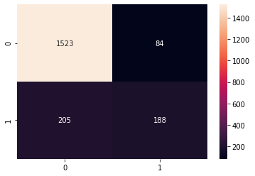

```python
import seaborn as sns
sns.heatmap(CM,fmt='2', annot=True)
```

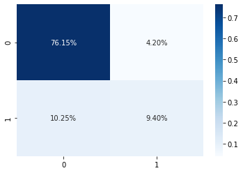

```python
# In Percent:
sns.heatmap(CM/np.sum(CM), annot=True,
            fmt='.2%', cmap='Blues');
```

```python
from sklearn.metrics import classification_report
cr=classification_report(Y_test,Y_pred)
print(cr)
```

```
              precision    recall  f1-score   support

           0       0.88      0.95      0.91      1607
           1       0.69      0.48      0.57       393

    accuracy                           0.86      2000
   macro avg       0.79      0.71      0.74      2000
weighted avg       0.84      0.86      0.84      2000
```

Accuracy is approximately 86%. Hence our model is indeed good. But, there is always a scope of improvement. The data is imbalanced, so we are considering another metrics too.